# DSP1

2023-10-05

## loading the Dataset

```r
bitcoin_mining <- read.csv("/Users/kusumsaichowdary/Documents/GitHub/Bitcoin_mining/bitcoin_mining.csv")
BCHAIN_HRATE <- read.csv("/Users/kusumsaichowdary/Documents/GitHub/Bitcoin_mining/BCHAIN-HRATE.csv")
regional_hashrate_global_1 <- read.csv("/Users/kusumsaichowdary/Documents/GitHub/Bitcoin_mining/Regional harshrate global 1.csv")
regional_hashrate_global_2 <- read.csv("/Users/kusumsaichowdary/Documents/GitHub/Bitcoin_mining/Regional harshrate global 2.csv")
regional_hashrate_china <- read.csv("/Users/kusumsaichowdary/Documents/GitHub/Bitcoin_mining/Regional harshrate in China.csv")
regional_hashrate_us <- read.csv("/Users/kusumsaichowdary/Documents/GitHub/Bitcoin_mining/Regional harshrate in US.csv")

bitcoin_mining =subset(bitcoin_mining, select = -c(X, X.1))

head(bitcoin_mining)
```

```
##         Date.and.Time power.MAX..GW power.MIN..GW power.GUESS..GW
## 1 2010-07-18T00:00:00      2.67e-05      2.24e-05        2.44e-05
## 2 2010-07-19T00:00:00      2.68e-05      2.26e-05        2.46e-05
## 3 2010-07-20T00:00:00      2.72e-05      2.29e-05        2.50e-05
## 4 2010-07-21T00:00:00      2.84e-05      2.39e-05        2.61e-05
## 5 2010-07-22T00:00:00      2.82e-05      2.37e-05        2.59e-05
## 6 2010-07-23T00:00:00      2.85e-05      2.40e-05        2.61e-05
##   annualised.consumption.MAX..TWh annualised.consumption.MIN..TWh
## 1                     0.000233717                     0.000196712
## 2                     0.000235075                     0.000197855
## 3                     0.000238699                     0.000200905
## 4                     0.000249343                     0.000209864
## 5                     0.000247305                     0.000208148
## 6                     0.000250023                     0.000210436
##   annualised.consumption.GUESS..TWh Lower.bound.efficiency..J.Th
```

[output cut: 27 more lines]

## Checking the Structure of data

```r
str(bitcoin_mining)
```

```
## 'data.frame':    5372 obs. of  15 variables:
##  $ Date.and.Time                    : chr  "2010-07-18T00:00:00" "2010-07-19T00:00:00" "2010-07-20T00:00:00" "2010-07-21T00:00:00" ...
##  $ power.MAX..GW                    : num  2.67e-05 2.68e-05 2.72e-05 2.84e-05 2.82e-05 2.85e-05 2.86e-05 2.99e-05 3.15e-05 3.23e-05 ...
##  $ power.MIN..GW                    : num  2.24e-05 2.26e-05 2.29e-05 2.39e-05 2.37e-05 2.40e-05 2.41e-05 2.52e-05 2.65e-05 2.72e-05 ...
##  $ power.GUESS..GW                  : num  2.44e-05 2.46e-05 2.50e-05 2.61e-05 2.59e-05 2.61e-05 2.62e-05 2.74e-05 2.88e-05 2.96e-05 ...
##  $ annualised.consumption.MAX..TWh  : num  0.000234 0.000235 0.000239 0.000249 0.000247 ...
##  $ annualised.consumption.MIN..TWh  : num  0.000197 0.000198 0.000201 0.00021 0.000208 ...
##  $ annualised.consumption.GUESS..TWh: num  0.000214 0.000215 0.000219 0.000229 0.000227 ...
##  $ Lower.bound.efficiency..J.Th     : num  14313700 14313700 14313700 14313700 14313700 ...
##  $ Estimated.efficiency..J.Th       : num  14313700 14313700 14313700 14313700 14313700 ...
##  $ Upper.bound.efficiency..J.Th     : num  14313700 14313700 14313700 14313700 14313700 ...
##  $ Hydro.only..MtCO2e               : num  4e-06 5e-06 5e-06 5e-06 5e-06 5e-06 5e-06 5e-06 5e-06 5e-06 ...
##  $ Estimated..MtCO2e                : num  0.000119 0.000119 0.000121 0.000127 0.000126 0.000127 0.000127 0.000133 0.00014 0.000144 ...
##  $ Coal.only..MtCO2e                : num  0.000214 0.000216 0.000219 0.000229 0.000227 0.000229 0.00023 0.000241 0.000253 0.00026 ...
##  $ Emission.intensity..gCO2e.kWh    : num  554 554 554 554 554 ...
##  $ Hash.rate.MH.s                   : num  4.43e+08 3.66e+08 3.92e+08 4.15e+08 3.86e+08 ...
```

#### Our Dataset contains 5,372 observations(rows) and 15 variables(columns). The structure of the bitcoin mining dataset reveals information related to power consumption, efficiency, CO2 emissions, and hash rates.

## Summary Statistics

```r
summary(bitcoin_mining)
```

```
##  Date.and.Time      power.MAX..GW     power.MIN..GW    power.GUESS..GW
##  Length:5372        Min.   : 0.0000   Min.   :0.0000   Min.   : 0.0000
##  Class :character   1st Qu.: 0.3918   1st Qu.:0.0312   1st Qu.: 0.1541
##  Mode  :character   Median : 2.1246   Median :0.3841   Median : 0.9052
##                     Mean   : 9.8297   Mean   :2.0394   Mean   : 3.9896
##                     3rd Qu.:15.4188   3rd Qu.:4.0495   3rd Qu.: 7.7106
##                     Max.   :56.0157   Max.   :8.9475   Max.   :15.0632
##                     NA's   :557       NA's   :557      NA's   :557
##  annualised.consumption.MAX..TWh annualised.consumption.MIN..TWh
##  Min.   :  0.0002                Min.   : 0.0002
##  1st Qu.:  3.4344                1st Qu.: 0.2731
##  Median : 18.6240                Median : 3.3674
##  Mean   : 86.1675                Mean   :17.8771
##  3rd Qu.:135.1615                3rd Qu.:35.4979
##  Max.   :491.0337                Max.   :78.4334
##  NA's   :557                     NA's   :557
##  annualised.consumption.GUESS..TWh Lower.bound.efficiency..J.Th
##  Min.   :  0.0002                  Min.   :      21
##  1st Qu.:  1.3507                  1st Qu.:      38
##  Median :  7.9351                  Median :      98
##  Mean   : 34.9727                  Mean   :  458086
##  3rd Qu.: 67.5915                  3rd Qu.:    9917
##  Max.   :132.0442                  Max.   :14313700
##  NA's   :557                       NA's   :557
##  Estimated.efficiency..J.Th Upper.bound.efficiency..J.Th Hydro.only..MtCO2e
##  Min.   :      31           Min.   :      46             Min.   :0.0000
##  1st Qu.:      68           1st Qu.:     167             1st Qu.:0.0284
##  Median :     261           Median :     766             Median :0.1666
##  Mean   :  771891           Mean   : 1292594             Mean   :0.7344
##  3rd Qu.:   36553           3rd Qu.:   75000             3rd Qu.:1.4194
##  Max.   :14313700           Max.   :14313700             Max.   :2.7729
##  NA's   :557                NA's   :557                  NA's   :557
##  Estimated..MtCO2e Coal.only..MtCO2e  Emission.intensity..gCO2e.kWh
##  Min.   : 0.0001   Min.   :  0.0002   Min.   :359.5
##  1st Qu.: 0.7563   1st Qu.:  1.3521   1st Qu.:512.8
##  Median : 4.2286   Median :  7.9431   Median :533.7
##  Mean   :17.9569   Mean   : 35.0076   Mean   :532.2
##  3rd Qu.:31.9601   3rd Qu.: 67.6591   3rd Qu.:559.0
##  Max.   :66.9083   Max.   :132.1762   Max.   :594.6
##  NA's   :557       NA's   :557        NA's   :557
##  Hash.rate.MH.s
##  Min.   :        0
##  1st Qu.:     3838
##  Median :  3210303
##  Mean   : 64397862
##  3rd Qu.:111495251
##  Max.   :506061817
##  NA's   :557
```

#### From the summary Statistics, we can see the distribution and range of each variable, as well as the presence of missing values.

## Data cleaning

```r
any(is.na(bitcoin_mining))
```

```
## [1] TRUE
```

```r
bitcoin_mining_cleanedData <- na.omit(bitcoin_mining)

str(bitcoin_mining_cleanedData)
```

```
## 'data.frame':    4815 obs. of  15 variables:
##  $ Date.and.Time                    : chr  "2010-07-18T00:00:00" "2010-07-19T00:00:00" "2010-07-20T00:00:00" "2010-07-21T00:00:00" ...
##  $ power.MAX..GW                    : num  2.67e-05 2.68e-05 2.72e-05 2.84e-05 2.82e-05 2.85e-05 2.86e-05 2.99e-05 3.15e-05 3.23e-05 ...
##  $ power.MIN..GW                    : num  2.24e-05 2.26e-05 2.29e-05 2.39e-05 2.37e-05 2.40e-05 2.41e-05 2.52e-05 2.65e-05 2.72e-05 ...
##  $ power.GUESS..GW                  : num  2.44e-05 2.46e-05 2.50e-05 2.61e-05 2.59e-05 2.61e-05 2.62e-05 2.74e-05 2.88e-05 2.96e-05 ...
##  $ annualised.consumption.MAX..TWh  : num  0.000234 0.000235 0.000239 0.000249 0.000247 ...
##  $ annualised.consumption.MIN..TWh  : num  0.000197 0.000198 0.000201 0.00021 0.000208 ...
##  $ annualised.consumption.GUESS..TWh: num  0.000214 0.000215 0.000219 0.000229 0.000227 ...
##  $ Lower.bound.efficiency..J.Th     : num  14313700 14313700 14313700 14313700 14313700 ...
##  $ Estimated.efficiency..J.Th       : num  14313700 14313700 14313700 14313700 14313700 ...
##  $ Upper.bound.efficiency..J.Th     : num  14313700 14313700 14313700 14313700 14313700 ...
##  $ Hydro.only..MtCO2e               : num  4e-06 5e-06 5e-06 5e-06 5e-06 5e-06 5e-06 5e-06 5e-06 5e-06 ...
##  $ Estimated..MtCO2e                : num  0.000119 0.000119 0.000121 0.000127 0.000126 0.000127 0.000127 0.000133 0.00014 0.000144 ...
##  $ Coal.only..MtCO2e                : num  0.000214 0.000216 0.000219 0.000229 0.000227 0.000229 0.00023 0.000241 0.000253 0.00026 ...
##  $ Emission.intensity..gCO2e.kWh    : num  554 554 554 554 554 ...
##  $ Hash.rate.MH.s                   : num  4.43e+08 3.66e+08 3.92e+08 4.15e+08 3.86e+08 ...
##  - attr(*, "na.action")= 'omit' Named int [1:557] 4816 4817 4818 4819 4820 4821 4822 4823 4824 4825 ...
##   ..- attr(*, "names")= chr [1:557] "4816" "4817" "4818" "4819" ...
```

```r
any(is.na(BCHAIN_HRATE))
```

```
## [1] FALSE
```

```r
any(is.na(regional_hashrate_global_1))
```

```
## [1] FALSE
```

```r
any(is.na(regional_hashrate_global_2))
```

```
## [1] FALSE
```

```r
any(is.na(regional_hashrate_china))
```

```
## [1] FALSE
```

```r
any(is.na(regional_hashrate_us))
```

```
## [1] FALSE
```

#### No misssing values in other csv files

## Data Visualization - Line plots

#### Line plots are particularly useful for visualizing time series data, as they allow us to observe trends, patterns, and fluctuations in the data over a continuous interval or time period.

## Plotting Estimated CO2 emissions over time

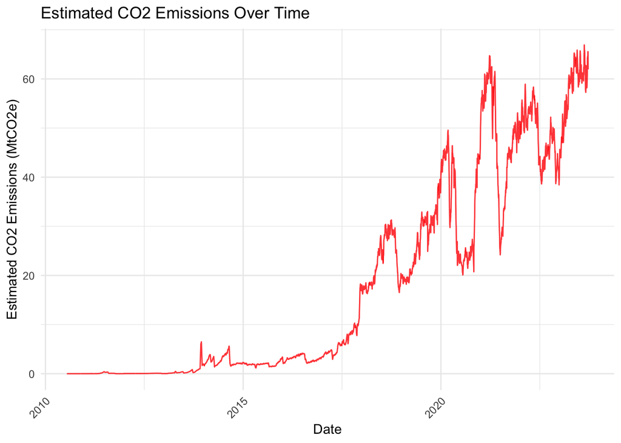

```r
library(ggplot2)


ggplot(bitcoin_mining_cleanedData, aes(x = as.Date(Date.and.Time), y = Estimated..MtCO2e)) +
  geom_line(color = "red", alpha = 0.8) +
  labs(title = "Estimated CO2 Emissions Over Time",
       x = "Date",
       y = "Estimated CO2 Emissions (MtCO2e)") +
  theme_minimal() +
  theme(axis.text.x = element_text(angle = 45, hjust = 1))
```

#### By this line plot, we can visualize how the estimated CO2 emissions due to Bitcoin mining have evolved over the years. This will help us understand the environmental implications associated with the growth of Bitcoin mining activities.

## Plotting Power Consumption over time

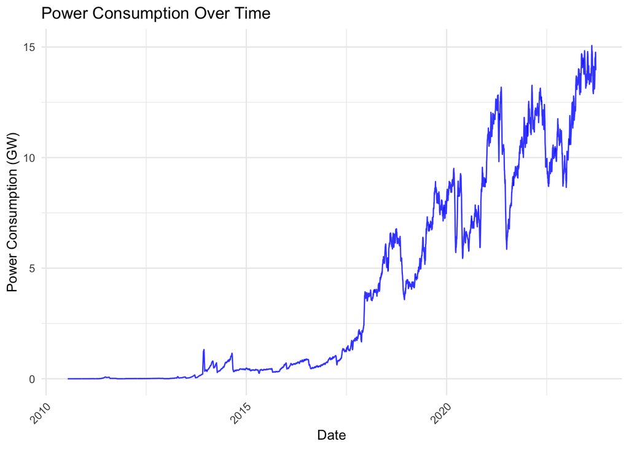

```r
library(ggplot2)


ggplot(bitcoin_mining_cleanedData, aes(x = as.Date(Date.and.Time), y = power.GUESS..GW)) +
  geom_line(color = "blue", alpha = 0.8) +
  labs(title = "Power Consumption Over Time",
       x = "Date",
       y = "Power Consumption (GW)") +
  theme_minimal() +
  theme(axis.text.x = element_text(angle = 45, hjust = 1))
```

#### By this line plot, We’ll visualize the power.GUESS..GW variable to understand the trend in power consumption related to Bitcoin mining over time.

## Plotting Hash rate over time

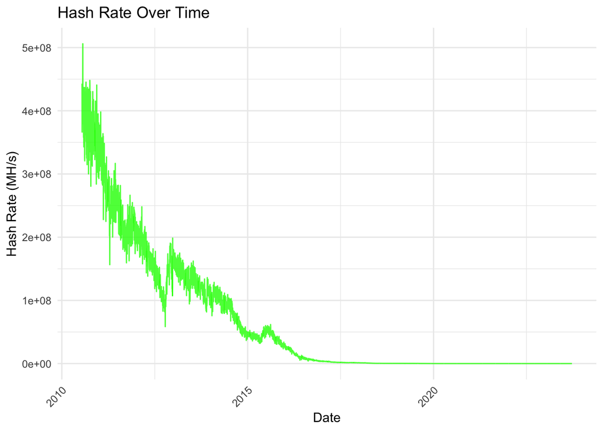

```r
ggplot(bitcoin_mining_cleanedData, aes(x = as.Date(Date.and.Time), y = Hash.rate.MH.s)) +
  geom_line(color = "green", alpha = 0.8) +
  labs(title = "Hash Rate Over Time",
       x = "Date",
       y = "Hash Rate (MH/s)") +
  theme_minimal() +
  theme(axis.text.x = element_text(angle = 45, hjust = 1))
```

#### The hash rate is a measure of the processing power of the Bitcoin network. A higher hash rate suggests more miners are participating, which also implies higher energy consumption.

#### We’ll visualize the Hash.rate.MH.s variable to see how the hash rate (indicative of Bitcoin mining activity) has evolved over time and this will provide insights into the growth and changes in Bitcoin mining activities.

## Plotting Emission Intensity over time

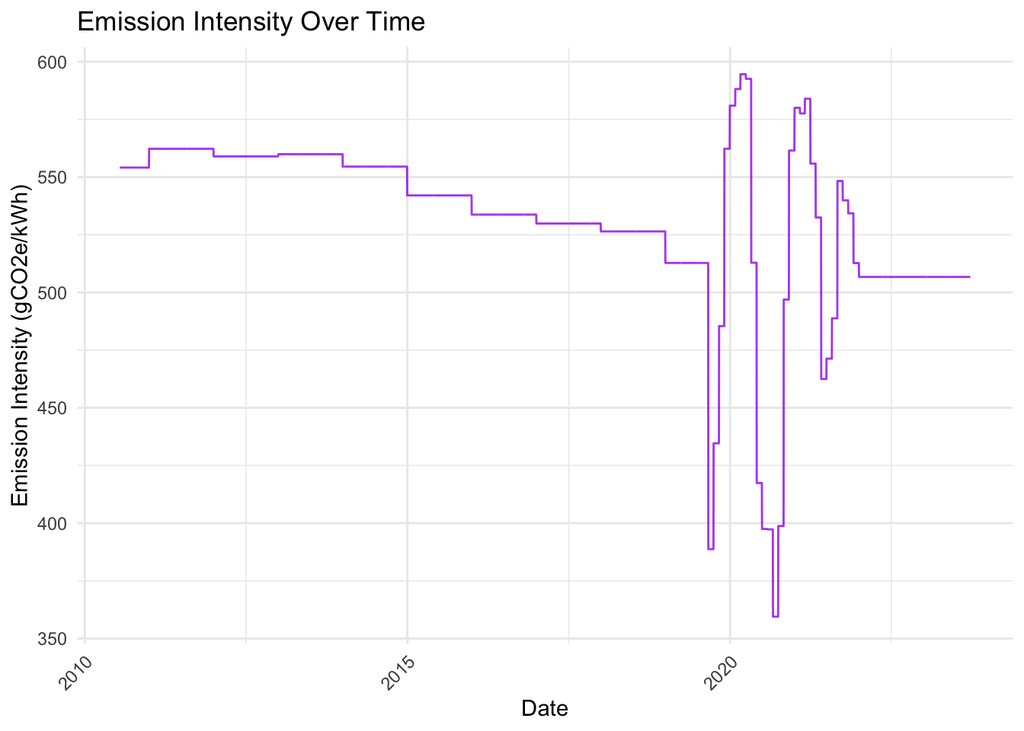

```r
ggplot(bitcoin_mining_cleanedData, aes(x = as.Date(Date.and.Time), y = Emission.intensity..gCO2e.kWh)) +
  geom_line(color = "purple", alpha = 0.8) +
  labs(title = "Emission Intensity Over Time",
       x = "Date",
       y = "Emission Intensity (gCO2e/kWh)") +
  theme_minimal() +
  theme(axis.text.x = element_text(angle = 45, hjust = 1))
```

#### By this line plot we can observe how the emission intensity related to Bitcoin mining has evolved over time. This will give insights into the environmental efficiency of Bitcoin mining practices over the years.

## Plotting Power Consumption (MAX and MIN) over time

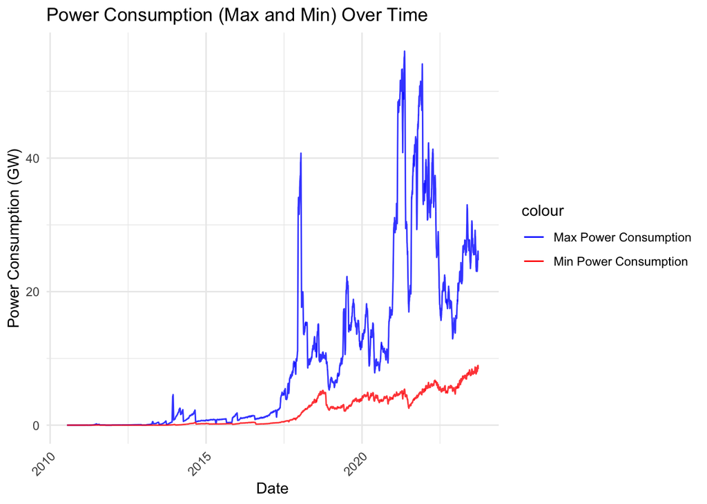

```r
ggplot(bitcoin_mining, aes(x = as.Date(Date.and.Time))) +
  geom_line(aes(y = power.MAX..GW, color = "Max Power Consumption"), alpha = 0.8) +
  geom_line(aes(y = power.MIN..GW, color = "Min Power Consumption"), alpha = 0.8) +
  labs(title = "Power Consumption (Max and Min) Over Time",
       x = "Date",
       y = "Power Consumption (GW)") +
  theme_minimal() +
  theme(axis.text.x = element_text(angle = 45, hjust = 1)) +
  scale_color_manual(values = c("Max Power Consumption" = "blue", "Min Power Consumption" = "red"))
```

#### This line plot compares the estimated maximum and minimum power consumption trends over time. The blue line represents the maximum power consumption, while the red line represents the minimum power consumption.

## Boxplot to visually inspect outliers

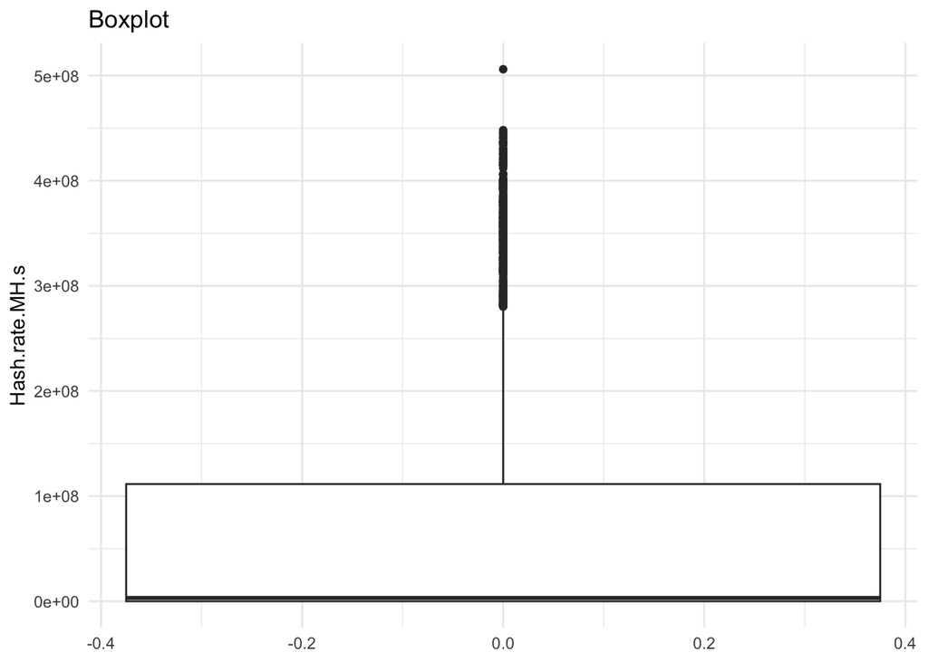

```r
library(ggplot2)



# Boxplot to visually inspect outliers
ggplot(bitcoin_mining_cleanedData, aes(y = Hash.rate.MH.s)) +
  geom_boxplot() +
  labs(title = "Boxplot ") +
  theme_minimal()
```